# 켤레사전분포

```python
from os.path import basename, exists

def download(url):
    filename = basename(url)
    if not exists(filename):
        from urllib.request import urlretrieve
        local, _ = urlretrieve(url, filename)
        print('Downloaded ' + local)

download('https://github.com/AllenDowney/ThinkBayes2/raw/master/soln/utils.py')

from utils import set_pyplot_params
set_pyplot_params()
```

## 18.01. 월드컵 문제

- **축구경기에서의 득점을, 경기 도중이라면 어떤 시점에서도 동일하게 일어날 수 있는 임의의 사건으로 가정하여, 포아송 프로세스를 사용해서 모델링**
- **감마분포를 사용해서 득점률 $\lambda$의 사전분포를 표현**
- **또한 득점수$k$의 확률을 구할 때 포아송 분포를 사용**

$$possion(\lambda) \sim \lambda^k e^{-\lambda} ~/~ k!$$

### 감마분포

- 감마분포에서 $\alpha$는 발생 사건 수를 나타내고, $\beta$는 소요 시간을 의미

$$f(x; \alpha, \beta) = \begin{cases} \frac{1}{\beta^{\alpha}\Gamma(\alpha)}x^{\alpha - 1}e^{-\frac{x}{\beta}}, & x > 0 \\ 0, & \text{else} \ x \end{cases}$$$$(\alpha > 0, \beta > 0)$$$$\Gamma(\alpha) = \int_{0}^{\infty}x^{\alpha - 1}e^{-x} dx$$

#### 감마분포 객체 생성

```python
from scipy.stats import gamma
```

```python
alpha = 1.4
dist = gamma(alpha)
```

#### 그리드 근사법을 통한 사전분포 생성

```python
import numpy as np
from utils import pmf_from_dist
```

```python
lams = np.linspace(0, 10, 101)
prior = pmf_from_dist(dist, lams)
```

#### $\lambda$의 각 가능한 값에 대해 4점 득점을 할 수 있는 가능도

```python
from scipy.stats import poisson
```

```python
k = 4
likelihood = poisson(lams).pmf(k)
```

#### 갱신

```python
posterior = prior * likelihood
posterior.normalize()
```

```
0.05015532557804499
```

## 18.02. 켤레사전분포

(1) $\text{Bin} (n , \theta)$ 의 켤레사전분포는 $\theta \sim \text{Beta} (\alpha, \beta)$

(2) $\text{Poi} ( \theta)$ 의 켤레사전분포는 $\theta \sim \text{Gamma} (\alpha, \beta)$

(3) 모분산 $\sigma^2$ 를 알 때, $N ( \mu , \sigma^2 )$ 의 켤레사전분포는 $\mu \sim N ( \mu_{0} , \tau_{0}^2 )$

(4) 모평균 $\mu$ 를 알 때, $N ( \mu , \sigma^2 )$ 의 켤레사전분포는 $\displaystyle \tau = {{1} \over {\sigma^2 }}$ 에 대해 $\tau \sim \text{Gamma} (\alpha, \beta)$

(5) $\lambda$ 를 알 때, $\text{Gamma} (a, \lambda)$ 의 켤레사전분포는 $\lambda \sim \text{Gamma} (\alpha, \beta)$

## 18.03. 감마-포아송 분포

### 감마사전분포의 PDF와 포아송 가능도의 PMF를 생성한 뒤, 베이지안 갱신 (사전분포와 가능도의 곱을 정규화) $\rightarrow$ 감마분포

- **감마사전분포의 PDF는 주어진 $\alpha$와 $\beta$에 대해 $\lambda$의 각 값에 대한 확률 밀도 (정규화 인수 생략)**

$$\lambda^{\alpha - 1}e^{-\frac{\lambda}{\beta}}$$

- **한 팀이 $t$ 게임동안 $k$만큼의 득점을 기록 $\rightarrow$ 이 데이터의 확률은 $k$, $\lambda$, $t$를 사용하는 포아송분포의 PMF (정규화 인수 생략)**

$${(\lambda )}^k e^{-\lambda t} $$

- **감마분포와 포아송분포의 함수 형태가 유사함을 확인**
- **감마분포와 포아송분포의 곱 (정규화 인수 생략)**

$$\lambda^{\alpha - 1+k}e^{-\frac{\lambda}{\beta}-\lambda t}$$

#### 매개변수 $\alpha + k$ 와 $\frac{1}{\beta}+t$를 사용하는, 정규화되지 않은 감마분포 형태

### 켤레사전분포

#### 감마사전분포 생성

```python
def make_gamma_dist(alpha, beta):

    """감마사전분포 생성"""
    dist = gamma(alpha, scale=1/beta)
    dist.alpha = alpha
    dist.beta = beta
    return dist
```

#### $\alpha=1.4$, $\beta=1$일 때의 감마분포

```python
alpha = 1.4
beta = 1

prior_gamma = make_gamma_dist(alpha, beta)
prior_gamma.mean()
```

```
1.4
```

#### 사후분포

- **득점수 $k=4$에, 경기수 $t=1$에 대한 사전분포 갱신**
- 그리드 근사를 통해 얻은 사후분포와 동일

```python
def update_gamma(prior, data):

    """감마사전분포 갱신"""
    k, t = data
    alpha = prior.alpha + k
    beta = prior.beta + t
    return make_gamma_dist(alpha, beta)
```

```python
data = 4, 1
posterior_gamma = update_gamma(prior_gamma, data)
```

```python
posterior_conjugate = pmf_from_dist(posterior_gamma, lams)
```

```python
from utils import decorate
```

```python
def decorate_rate(title=''):
    decorate(xlabel='Goal scoring rate (lam)', ylabel='PMF', title=title)
```

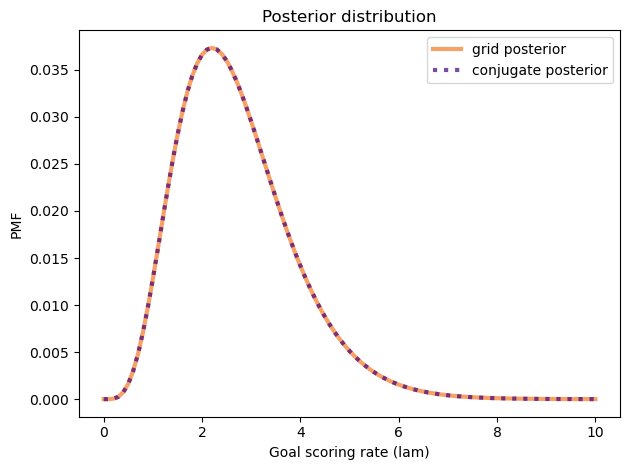

```python
posterior.plot(label='grid posterior', color='C1')
posterior_conjugate.plot(label='conjugate posterior',  color='C4', ls=':')

decorate_rate('Posterior distribution')
```

```python
np.allclose(posterior, posterior_conjugate)
```

```
True
```

## 18.04. 베타-이항분포

### 그리드 근사

#### $p$에 대한 균등사전분포

```python
from utils import make_uniform
```

```python
xs = np.linspace(0, 1, 101)
uniform = make_uniform(xs, 'uniform')
```

#### 이항분포를 사용하여 250회의 시도 중 140회 앞면이 나오는 동전에 대한 가능도 계산

```python
from scipy.stats import binom
```

```python
k, n = 140, 250
xs = uniform.qs
likelihood = binom.pmf(k, n, xs)
```

#### 베이지안 갱신

```python
posterior = uniform * likelihood
posterior.normalize()
```

```
0.003944617569326651
```

### 베타분포

- **베타분포는 0과 1사이값을 가지며, 확률 등의 분포를 나타내기에 적절**
- **$\alpha$는 관측한 성공 횟수와 관련, $\beta$는 실패 횟수와 관련**

$$\begin{align} \text{Beta}(x;\alpha,\beta) & = \frac{\Gamma(\alpha +\beta)}{\Gamma(\alpha)\Gamma(\beta)}\, x^{\alpha-1}(1-x)^{\beta-1} \tag{8.7.2} \end{align}$$

#### `scipy.stats.beta(alpha, beta)` : 베타분포 객체 생성

```python
import scipy.stats
```

```python
def make_beta(alpha, beta):

    """베타분포 객체 생성"""
    dist = scipy.stats.beta(alpha, beta)
    dist.alpha = alpha
    dist.beta = beta
    return dist
```

- **$\alpha=1$, $\beta=1$인 베타분포**

```python
alpha = 1
beta = 1

prior_beta = make_beta(alpha, beta)
```

### 베타사전분포의 PDF와, 이항 가능도의 PMF를 생성한 뒤, 베이지안 갱신 (사전분포와 가능도의 곱을 정규화) $\rightarrow$ 베타분포

- **베타사전분포의 PDF는 주어진 $\alpha$와 $\beta$에 대해, $p$의 각 값에 대한 확률 밀도 (정규화 인수 생략)**

$$x^{\alpha-1}(1-x)^{\beta - 1}$$

- **$k$, $n$, $x$ 매개변수를 사용하는 이항분포의 PMF (정규화 인수 생략)**

$$x^k (1-x)^{n-k}$$

- **베타분포와 이항분포의 함수 형태가 유사함을 확인**
- **베타분포와 이항분포의 곱 (정규화 인수 생략)**

$$x^{\alpha-1+k}(1-x)^{\beta-1+n-k}$$

#### 매개변수 $\alpha + k$ 와 $\beta+n-k$를 사용하는, 정규화되지 않은 베타분포 형태

### 켤레사전분포

#### 베타사전분포 갱신

```python
def update_beta(prior, data):

    """베타사전분포 갱신"""
    k, n = data
    alpha = prior.alpha + k
    beta = prior.beta + n - k
    return make_beta(alpha, beta)
```

```python
data = 140, 250
posterior_beta = update_beta(prior_beta, data)
```

```python
posterior_conjugate = pmf_from_dist(posterior_beta, xs)
```

#### 그리드 근사를 통해 얻은 사후분포와 동일

```python
def decorate_euro(title):
    decorate(xlabel='Proportion of heads (x)', ylabel='Probability', title=title)
```

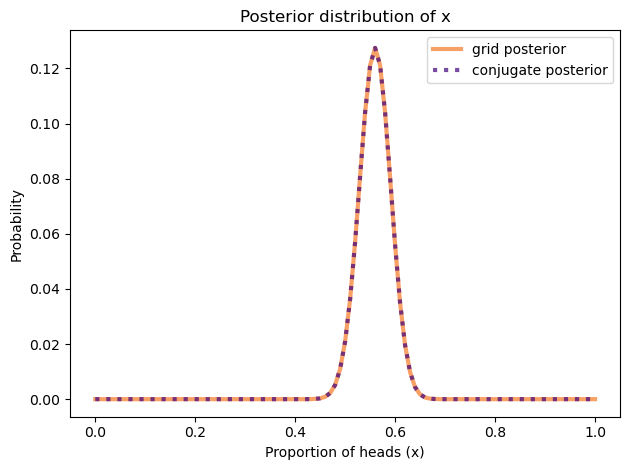

```python
posterior.plot(label='grid posterior', color='C1')
posterior_conjugate.plot(label='conjugate posterior', color='C4', ls=':')

decorate_euro(title='Posterior distribution of x')
```

```python
np.allclose(posterior, posterior_conjugate)
```

```
True
```

## 18.05. 다항-디리클레분포

> 사자, 호랑이, 곰만 있는 야생동물 보호구역에서, 각각의 동물이 몇 마리 있는지는 알 수 없음

> 관광중 사자 3마리, 호랑이 2마리, 곰 1마리를 발견

> 각 동물이 둘러본 지역에서 동일한 확률로 나타난다고 가정한다면, 다음에 볼 동물이 곰일 확률은?

#### 각 종이 얼마나 있는지 추정이 필요 $\rightarrow$ 각 종의 비율이 어떻게 되는지 파악

### 각 종별 비율을 아는 경우 $\rightarrow$ 다항분포 사용

```python
from scipy.stats import multinomial
```

```python
data = 3, 2, 1
n = np.sum(data)
ps = 0.4, 0.3, 0.3

multinomial.pmf(data, n, ps)
```

[output not shown]

## 18.06. 다항-디리클레분포

### 디리클레분포

- **베타분포가 0과 1사이의 값을 가지는 단일(univariate) 확률변수의 베이지안 모형에 사용된다며**

  **디리클레분포는 0과 1사이의 사이의 값을 가지는 다변수(multivariate) 확률변수의 베이지안 모형에 사용 (다항분포)**

$$\begin{split} \begin{align} \begin{aligned} \text{Dir}(x;\alpha) &= \text{Dir}(x_1, x_2, \cdots, x_K; \alpha_1, \alpha_2, \cdots, \alpha_K) \\ &= \frac{1}{\mathrm{B}(\alpha_1, \alpha_2, \cdots, \alpha_K)} \prod_{i=1}^K x_i^{\alpha_i - 1} \end{aligned} \ \end{align} \end{split}$$$$\begin{align} 0 \leq x_i \leq 1, \;\;\; \sum_{i=1}^{K} x_i = 1 \end{align}$$

- **$α=(α_1,α_2,…,α_K)$ : 매개변수**
- **$B(α_1,α_2,⋯,α_K)$ : 베타함수**

$$\begin{align} \mathrm{B}(\alpha_1, \alpha_2, \cdots, \alpha_K) = \frac{\prod_{i=1}^K \Gamma(\alpha_i)} {\Gamma\bigl(\sum_{i=1}^K \alpha_i\bigr)} \end{align}$$

- **베타분포는 $K=2$인 디리클레분포**
  - 즉 $x_1=x,\; x_2=1−x,\;α_1=\alpha,\; α_2=\beta$ 로 하면

$$\begin{split} \begin{align} \begin{aligned} \text{Beta}(x;a,b) &= \frac{\Gamma(a+b)}{\Gamma(a)\Gamma(b)}\, x^{a-1}(1-x)^{b-1} \\ &= \frac{\Gamma(\alpha_1+\alpha_2)}{\Gamma(\alpha_1)\Gamma(\alpha_2)}\, x_1^{\alpha_1 - 1} x_2^{\alpha_2 - 1} \\ &= \frac{1}{\mathrm{B}(\alpha_1, \alpha_2)} \prod_{i=1}^2 x_i^{\alpha_i - 1} \end{aligned} \end{align} \end{split}$$

#### `scipy.stats.dirichlet(alpha)` : `alpha`를 매개변수 목록으로 가지는 디리클레분포 객체 생성

```python
from scipy.stats import dirichlet
```

```python
alpha = 1, 2, 3
dist = dirichlet(alpha)
```

#### 디리클레분포의 확률밀도함수값의 크기는, 매개변수 목록 $\alpha$의 크기인 $K$개

#### $K$개의 매개변수 목록내 개별 매개변수의 범위는 0과 1 사이이며, 합은 1

#### 이 값은 상호 배타적이며, 전체 포괄적인 결과 집합이므로, 확률로 해석할 수 있음

```python
dist.rvs()
```

```
array([[0.06220481, 0.51807062, 0.41972457]])
```

```python
dist.rvs().sum()
```

```
1.0
```

#### 1,000개의 임의의 값 추출

```python
sample = dist.rvs(1000)
sample.shape
```

```
(1000, 3)
```

#### 각 개별 매개변수에 대한 누적분포함수 값

- 열 0은 가장 값이 작은 매개변수에 해당하고, 가장 낮은 확률값을 가짐
- 열 2는 가장 값이 큰 매개변수에 대응하고, 가장 높은 확률값을 가짐

```python
from empiricaldist import Cdf
```

```python
cdfs = [Cdf.from_seq(col) for col in sample.transpose()]
```

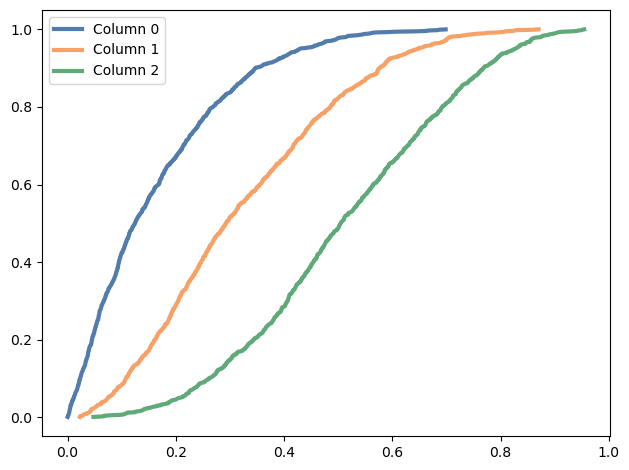

```python
for i, cdf in enumerate(cdfs):
    label = f'Column {i}'
    cdf.plot(label=label)

decorate()
```

#### 디리클레 사후분포에 대한 각 개별 매개변수의 주변분포는 베타분포

- **예) 디리클레분포의 매개변수 중 하나인 $\alpha_1$의 주변분포는,**

```python
alpha
```

```
(1, 2, 3)
```

```python
def marginal_beta(alpha, i):
    """디리클레 분포의 i번째 주변분포"""
    total = np.sum(alpha)
    return make_beta(alpha[i], total-alpha[i])
```

```python
marginals = [marginal_beta(alpha, i) for i in range(len(alpha))]
```

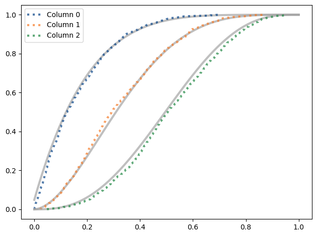

```python
xs = np.linspace(0, 1, 101)

for i in range(len(alpha)):
    label = f'Column {i}'

    pmf = pmf_from_dist(marginals[i], xs)
    pmf.make_cdf().plot(color='C5')

    cdf = cdfs[i]
    cdf.plot(label=label, ls=':')

decorate()
```

### 사전분포가 $\alpha=\alpha_1, \alpha_2. \dots. \alpha_k$에 대한 디리클레 분포이고

### $o = o_1, o_2. \dots .o_k$가 관측값인 경우

### 사후분포는 $\alpha + o = \alpha_1+o_1,\;\alpha_2+o_2 \dots.\;\alpha_k + o_k$에 대한 디리클레분포를 따름

### 사자, 호랑이, 곰 문제

> 사자, 호랑이, 곰만 있는 야생동물 보호구역에서, 각각의 동물이 몇 마리 있는지는 알 수 없음

> 관광중 사자 3마리, 호랑이 2마리, 곰 1마리를 발견

> 각 동물이 둘러본 지역에서 동일한 확률로 나타난다고 가정한다면, 다음에 볼 동물이 곰일 확률은?

#### 각 종의 비율이 1:1:1이고, 관측값이 3:2:1일 때

```python
prior_alpha = np.array([1, 1, 1])
data = 3, 2, 1
```

```python
posterior_alpha = prior_alpha + data
```

#### 종별 사후주변분포

- 곰

```python
marginal_bear = marginal_beta(posterior_alpha, 2)
marginal_bear.mean()
```

```
0.2222222222222222
```

- 사자

```python
marginal_lion = marginal_beta(posterior_alpha, 0)
marginal_lion.mean()
```

```
0.4444444444444444
```

- 호랑이

```python
marginal_tiger = marginal_beta(posterior_alpha, 1)
marginal_tiger.mean()
```

```
0.3333333333333333
```

```python
import pandas as pd
```

```python
dist = dirichlet(posterior_alpha)

index = ['lion', 'tiger', 'bear']
pd.DataFrame(dist.mean(), index, columns=['prob'])
```

|  | prob |
| --- | --- |
| lion | 0.444444 |
| tiger | 0.333333 |
| bear | 0.222222 |

## 18.07. 감마-지수분포

### 감마사전분포의 PDF와 지수 가능도의 PMF를 생성한 뒤, 베이지안 갱신 (사전분포와 가능도의 곱을 정규화) $\rightarrow$ 감마분포

- **감마사전분포의 PDF는 주어진 $\alpha$와 $\beta$에 대해 $\lambda$의 각 값에 대한 확률 밀도 (정규화 인수 생략)**

$$\lambda^{\alpha - 1}e^{-\frac{\lambda}{\beta}}$$

- **한 팀이 게임에서 첫 득점까지 $t$만큼의 시간을 소요 $\rightarrow$ 이 데이터의 확률은 $\lambda$, $t$를 사용하는 지수분포의 PMF**

$$\lambda e^{-\lambda t}$$

- **감마분포와 지수분포의 함수 형태가 유사함을 확인**
- **감마분포와 지수분포의 곱 (정규화 인수 생략)**

$$\lambda^{\alpha-1+1} e^{-(\frac{1}{\beta} + t) \lambda} $$

#### 감마사전분포 생성

```python
alpha = 1.4
beta = 1

prior_gamma = make_gamma_dist(alpha, beta)
prior_gamma.mean()
```

```
1.4
```

#### 첫 골이 11분 후에 발생

```python
data = 1, 11/90
posterior1 = update_gamma(prior_gamma, data)
```

#### 두 번째 골은 그 이후 12분 후에 발생

```python
data = 1, 12/90
posterior2 = update_gamma(posterior1, data)
```

```python
prior_gamma.mean(), posterior1.mean(), posterior2.mean()
```

```
(1.4, 2.1386138613861387, 2.7079646017699113)
```

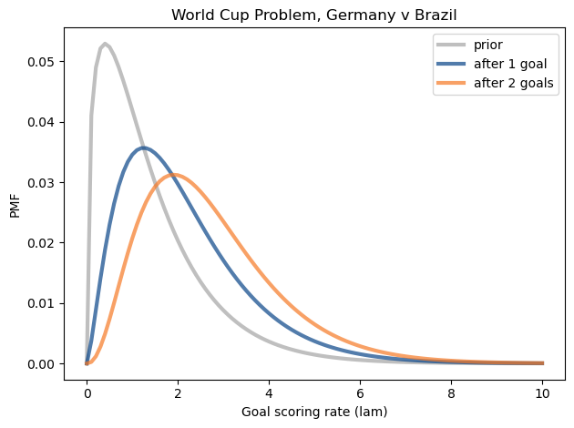

```python
pmf_from_dist(prior_gamma, lams).plot(color='C5', label='prior')
pmf_from_dist(posterior1, lams).plot(label='after 1 goal')
pmf_from_dist(posterior2, lams).plot(label='after 2 goals')

decorate_rate(title='World Cup Problem, Germany v Brazil')
```

## 18.08. 예제

### (1)

### 삼각사전분포 그리드 근사

#### $p$에 대한 삼각사전분포 생성

```python
from empiricaldist import Pmf
```

```python
ramp_up = np.arange(50)
ramp_down = np.arange(50, -1, -1)

a = np.append(ramp_up, ramp_down)
xs = uniform.qs

triangle = Pmf(a, xs, name='triangle')
triangle.normalize()
```

```
2500
```

```python
import matplotlib.pyplot as plt
```

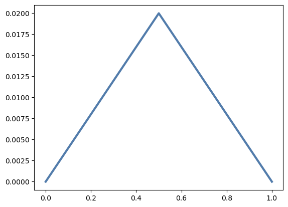

```python
triangle.plot()
plt.show()
```

#### 삼각사전분포와, 250회의 시도 중 140회 앞면이 나오는 동전에 대한 이항가능도를 통한 갱신

```python
k, n = 140, 250
likelihood = binom.pmf(k, n, xs)

posterior = triangle * likelihood
posterior.normalize()
```

```
0.007008842590059086
```

### 켤레사전분포

#### $\alpha=1,\;\beta=1$인 베타분포는 균등분포와 동일

```python
alpha = 1
beta = 1

prior_beta = make_beta(alpha, beta)
prior_beta.mean()
```

```
0.5
```

```python
prior_pmf = pmf_from_dist(prior_beta, xs)
```

**삼각사전분포와, 베타사전분포(=균등사전분포)의 비교**

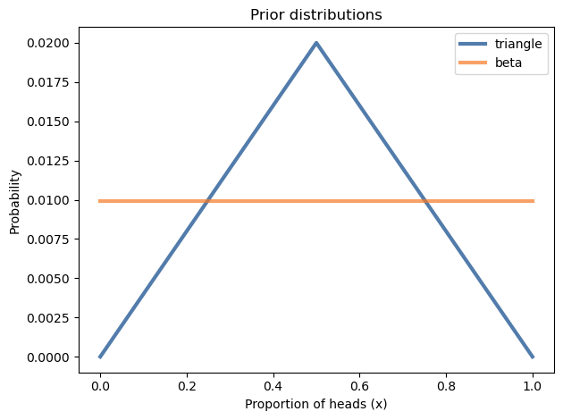

```python
triangle.plot(label='triangle')
prior_pmf.plot(label='beta')

decorate_euro('Prior distributions')
```

#### 위 베타사전분포와, 250회의 시도 중 140회 앞면이 나오는 동전의 가능도를 통한 갱신

```python
data = 140, 250
posterior_beta = update_beta(prior_beta, data)
posterior_beta.mean()
```

```
0.5595238095238095
```

```python
posterior_conjugate = pmf_from_dist(posterior_beta, xs)
```

### 삼각사전분포를 그리드 근사하여 갱신한 사후분포와, 베타사전분포(=균일사전분포)의 켤레함수를 사용한 사후분포가 유사함을 확인

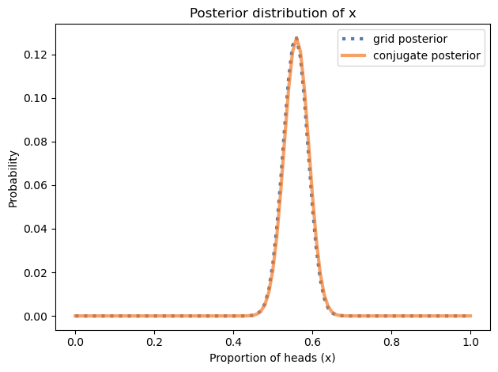

```python
posterior.plot(label='grid posterior', ls=':')
posterior_conjugate.plot(label='conjugate posterior')

decorate(xlabel='Proportion of heads (x)', ylabel='Probability', title='Posterior distribution of x')
```

### (2)

3Blue1Brown 수학 유튜브 채널의 [영상](https://www.youtube.com/watch?v=8idr1WZ1A7Q) 중

> 인터넷에서 물 건 하나를 사려고 찾아보니, 3명의 판매자가 동일한 제품을 동일한 가격으로 팔고 있었다. 한 판매자는 100% 긍정적 평점이 있었지만, 후기 수가 10개뿐이었다. 다른 판매자는 96% 긍정적 평점이었고 총 후기는 50개였다. 나머지 한 판매자는 93%의 긍정적 평점을 받았고, 총 후기는 200개였다. 이 때 어느 판매자에게서 물건을 살 것인가?

#### 판매자별 만족스러운 서비르를 한 후 긍정적 평점을 받을 확률 $x$가 있고, 이 중 $x$가 가장 높은 판매자를 선택

#### 1. 사전분포로는 $\alpha=8$, $\beta=2$인 베타분포 사용

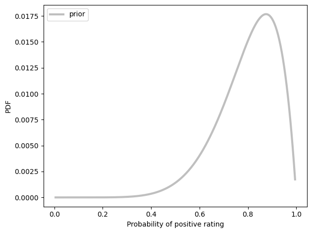

```python
prior = make_beta(8, 2)

xs = np.linspace(0.005, 0.995, 199)
prior_pmf = pmf_from_dist(prior, xs)
prior_pmf.plot(color='C5', label='prior')

decorate(xlabel='Probability of positive rating',ylabel='PDF')
```

#### 2. 데이터를 사용해서 3명의 판매자에 대한 사전분포를 갱신하고, 사후분포 확인

- 각 판매자별 긍정적 평점 개수 및 비율을 활용하여 갱신
- **2번째 판매자의 사후분포 평균이 가장 높음**

```python
data1 = 10, 10
data2 = 48, 50
data3 = 186, 200
```

```python
seller1 = update_beta(prior, data1)
seller2 = update_beta(prior, data2)
seller3 = update_beta(prior, data3)
```

```python
seller1_pmf = pmf_from_dist(seller1, xs)
seller2_pmf = pmf_from_dist(seller2, xs)
seller3_pmf = pmf_from_dist(seller3, xs)
```

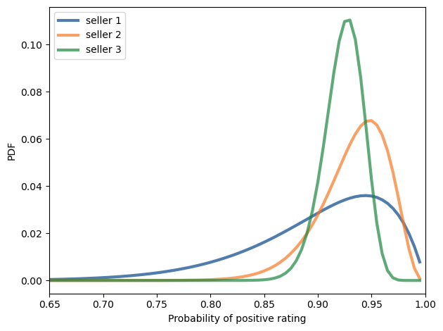

```python
seller1_pmf.plot(label='seller 1')
seller2_pmf.plot(label='seller 2')
seller3_pmf.plot(label='seller 3')

decorate(xlabel='Probability of positive rating', ylabel='PDF', xlim=(0.65, 1.0))
```

```python
seller1.mean(), seller2.mean(), seller3.mean()
```

```
(0.9, 0.9333333333333333, 0.9238095238095239)
```

#### 3. 가장 높은 사후평균을 가진 판매자의 $x$가 실제로 높을 확률은?

- 각 판매자별 사후분포로부터 10000개의 샘플 추출
- **10,000 번의 추출표본에서, 2번째 판매자가 다른 판매자보다 좋은 평점을 받은 비율이 48.15%**

```python
iters = 10000
a = np.empty((3, iters))

a[0] = seller1.rvs(iters)
a[1] = seller2.rvs(iters)
a[2] = seller3.rvs(iters)
```

```python
best = np.argmax(a, axis=0)
Pmf.from_seq(best)
```

|  | probs |
| --- | --- |
| 0 | 0.2907 |
| 1 | 0.4815 |
| 2 | 0.2278 |

#### 4. $\alpha=0.7$, $\beta=0.5$인 베타사전분포 사용

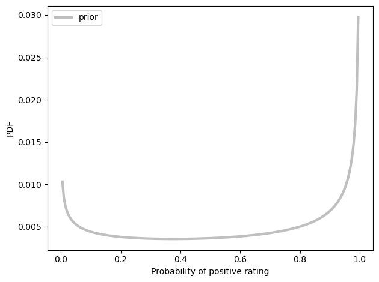

```python
prior = make_beta(0.7, 0.5)

xs = np.linspace(0.005, 0.995, 199)
prior_pmf = pmf_from_dist(prior, xs)
prior_pmf.plot(color='C5', label='prior')

decorate(xlabel='Probability of positive rating',ylabel='PDF')
```

```python
seller1 = update_beta(prior, data1)
seller2 = update_beta(prior, data2)
seller3 = update_beta(prior, data3)

seller1_pmf = pmf_from_dist(seller1, xs)
seller2_pmf = pmf_from_dist(seller2, xs)
seller3_pmf = pmf_from_dist(seller3, xs)
```

```python
seller1.mean(), seller2.mean(), seller3.mean()
```

```
(0.9553571428571429, 0.951171875, 0.9279324055666004)
```

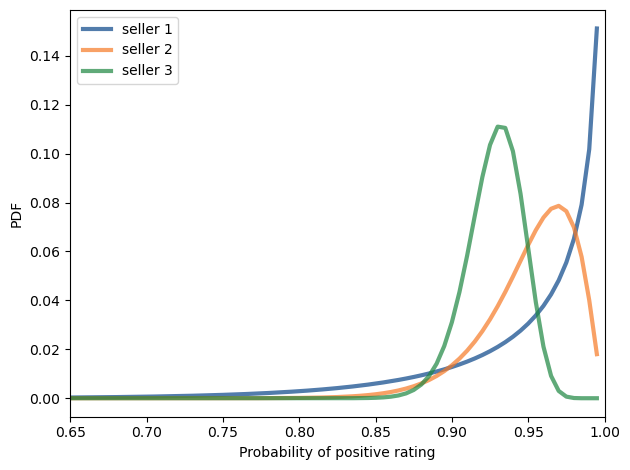

```python
seller1_pmf.plot(label='seller 1')
seller2_pmf.plot(label='seller 2')
seller3_pmf.plot(label='seller 3')

decorate(xlabel='Probability of positive rating', ylabel='PDF', xlim=(0.65, 1.0))
```

```python
iters = 10000
a = np.empty((3, iters))

a[0] = seller1.rvs(iters)
a[1] = seller2.rvs(iters)
a[2] = seller3.rvs(iters)
```

```python
best = np.argmax(a, axis=0)
Pmf.from_seq(best)
```

|  | probs |
| --- | --- |
| 0 | 0.6342 |
| 1 | 0.3125 |
| 2 | 0.0533 |